# Discrete Movement Models

Elie Gurarie

2024-05-18

## 1D Random Walk

$$X \sim
\text{RW}_{1d}(\sigma)$$

```r
sigma = 2
Z <- cumsum(rnorm(100, sd = sigma))
```

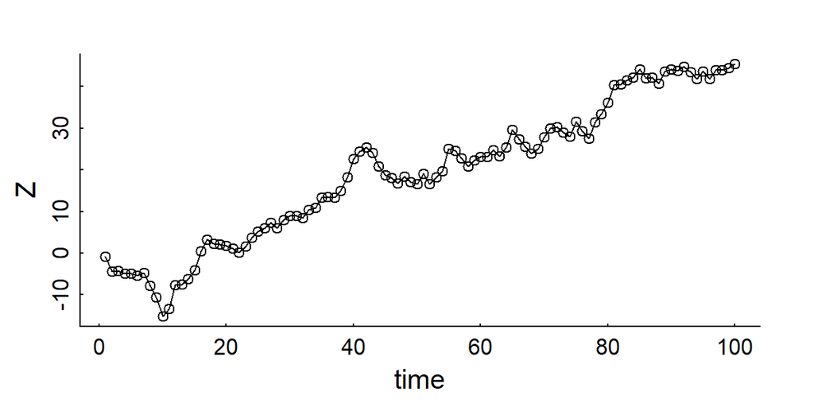

### Properties

$$\text{E}(Z_t) = 0$$
$$\text{Var}(Z_t) = \sigma^2 t$$
On *average* goes nowhere, over time goes to $\infty$ (unconstrained)

## 2D Random Walk

$${\bf Z} \sim
\text{RW}_{2d}(\sigma)$$
$${\bf Z}_t =
{\bf Z}_{t-1} + \sigma{\bf W}_t$$

boldfacing means 2-d vector, but will drop going forward.

```r
sigma <- 3; n <- 100
Z <- cumsum(rnorm(n, sd = sigma)) +
  1i*cumsum(rnorm(n, sd = sigma))
```

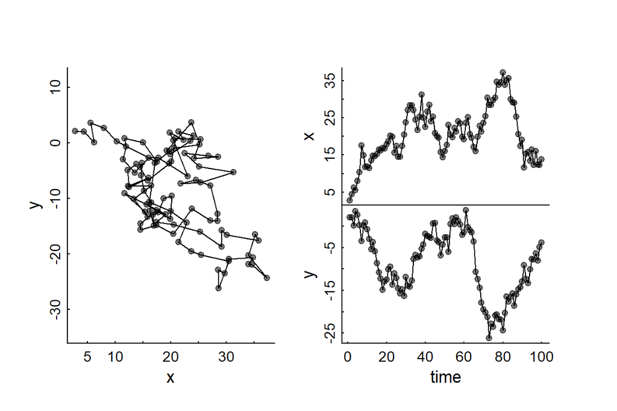

### Properties

$$\text{E}({\bf Z}_t) = \{0,0\};\,\,
\text{Var}(|{\bf Z}_t|) = 2 \sigma^2 t$$
Step & turning angles:

$$\theta \sim \text{Unif}(-\pi,
\pi)$$

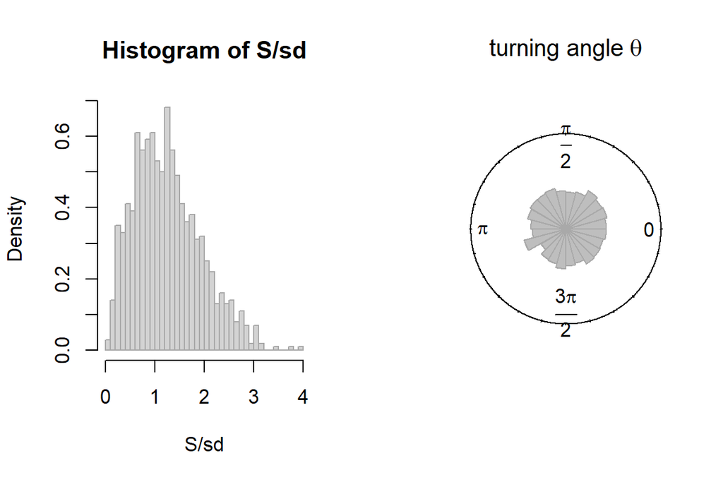

## 1D Auto-regression process

$$X \sim \text{AR}_{1d}(\phi,
\sigma)$$

```r
sigma = 2; phi = 0.8; n = 100;
X <- c(rnorm(1,0,sigma), rep(NA, n-1))
for(i in 2:n)
  X[i] <- phi*X[i-1] + rnorm(1,0,sigma)
```

By the way: start making functions!

```r
AR1D <- function(n = 100, sigma = 2, phi = 0.8, mu = 0){
  X <- c(rnorm(1,0,sigma), rep(NA, n-1))
  for(i in 2:n)
    X[i] <- phi*X[i-1] + rnorm(1,0,sigma)
  X + mu
}
```

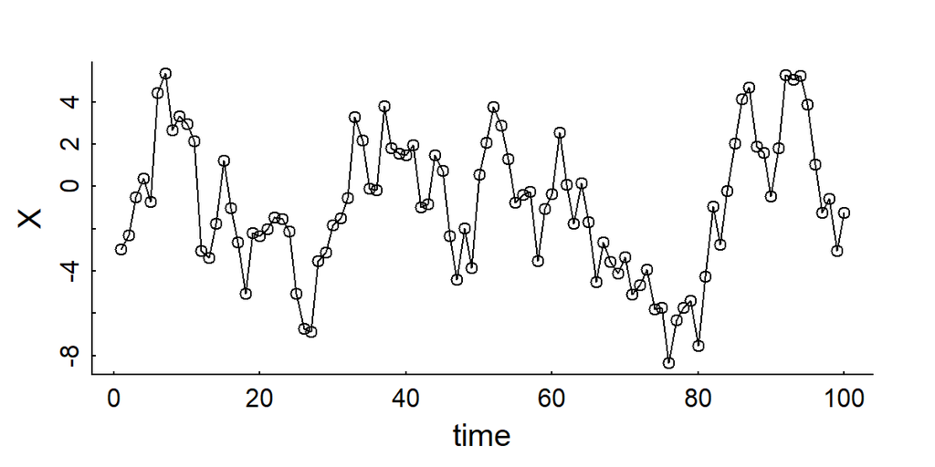

### Properties

$$\text{E}(X_t) = 0$$
$$\text{Var}(X_t) = {\sigma^2 \over
1-\phi^2}$$
(Auto)-regresses to mean (easily rescaled to $\mu \neq 0$).

Spatially constrained!

## 2D autoregressive walk

$${\bf Z} \sim \text{AR}_{2d}(\phi,
\sigma)$$
$${\bf Z}_t = \phi {\bf
Z}_{t-1} + \sigma {\bf W}_t$$

Where everything is 2D. And easily scaled to a different mean $\bf m$

```r
AR2D <- function(n = 100, phi = 0, sigma = 1, mu = 0){
  X <- AR1D(n, sigma, phi, Re(mu))
  Y <- AR1D(n, sigma, phi, Im(mu))
  X + 1i*Y
}
```

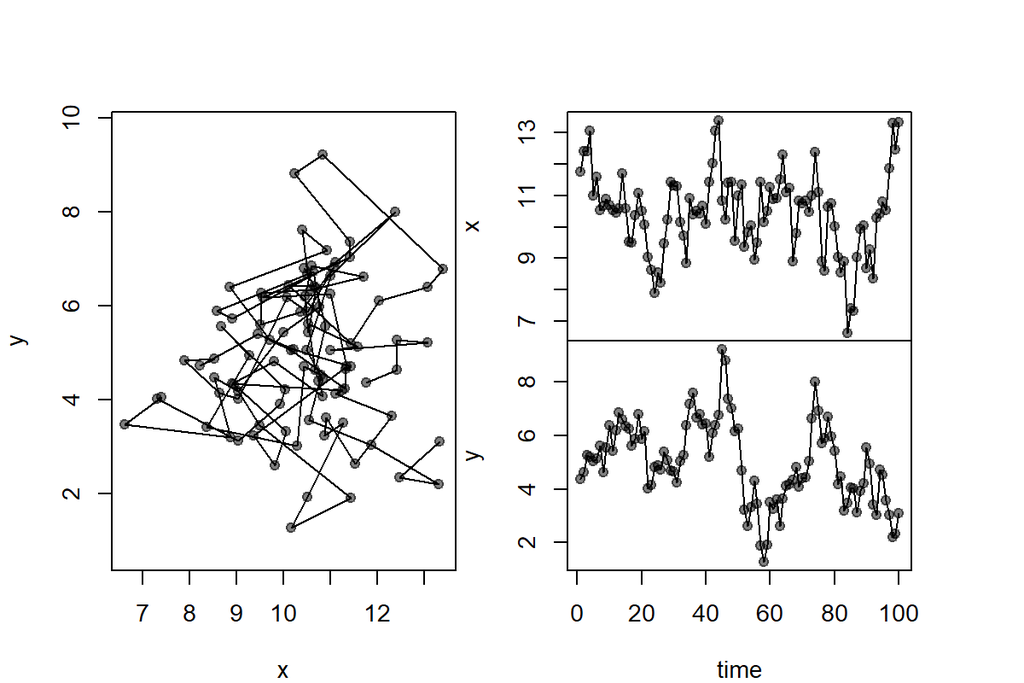

```r
scantrack(AR2D(100, 0.8, 1, 10+1i*5), cex = 1)
```

### Properties

Spatially constrained in 2D!

Actually looks kind of like home ranging. In fact, the 95% home-ranging area is:

$$A \approx {6 \pi \sigma^2 \over 1 -
\phi^2 }$$
(Where $6 \approx -2\log(\alpha)$, $\alpha = 5\%$)

Rewrite in terms of “steps” (displacements):

$${\bf Z}_t = {\bf Z}_{t-1} - (1-\phi){\bf
Z}_{t-1} + \sigma {\bf W}_t$$
$${\bf
S}_t = - (1-\phi){\bf Z}_{t-1} + \sigma {\bf W}_t$$

This means that the *step* process itself is NOT stationary / independent, but depends on **absolute location**.

Specifically, the urge to “go home” is proportional to the distance from home.

And, of course, there is auto-correlation in the locations:

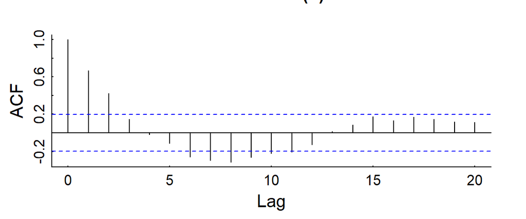

```r
Z <- AR2D(100, 0.8, 1, 10+1i*5)
acf(Re(Z))
```

But NOT in the steps themselves:

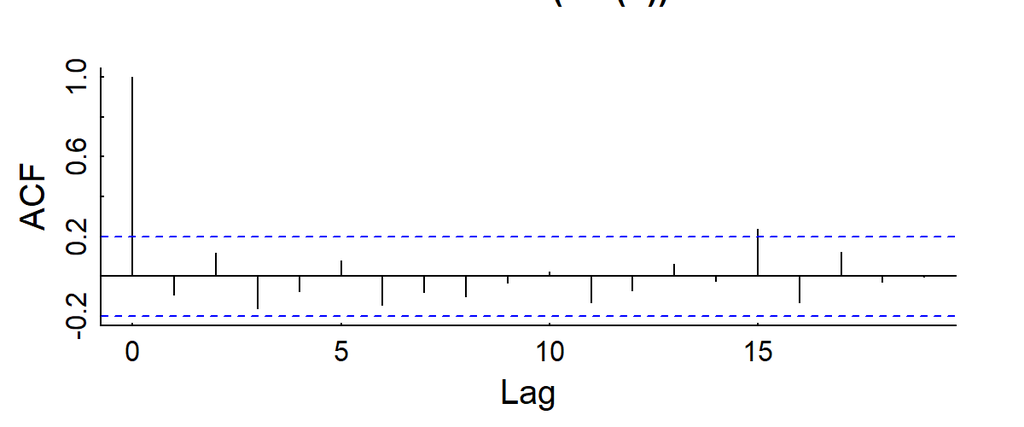

```r
acf(Re(diff(Z)))
```

## Correlated Random Walk

Basically:

$$Z_t = Z_{t-1} + S_t$$

- $\theta = \text{Arg}(S) \sim \text{some distribution}$
- $|S| \sim \text{some distribution}$

> **The famous one:**

[figure not shown]

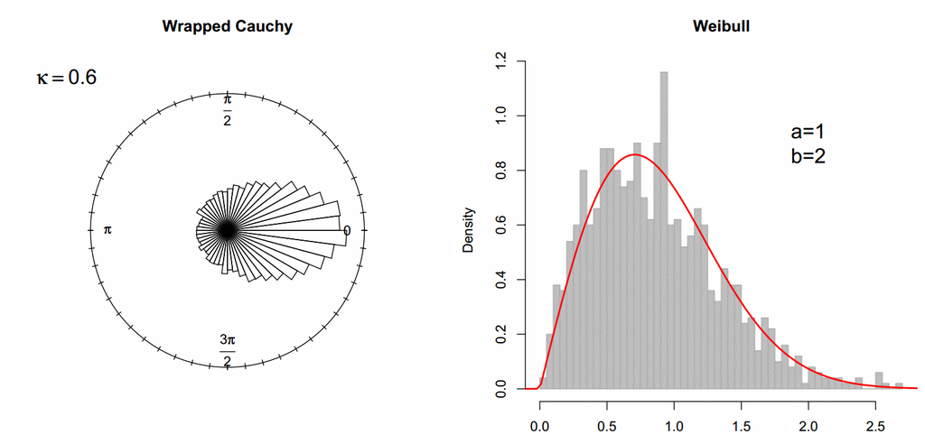

> **The totally forgotten one:**

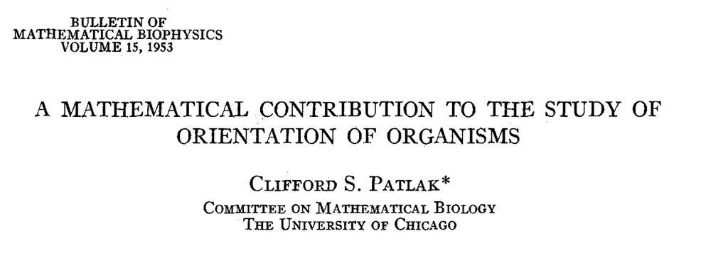

```r
require(circular)

CRW <- function(n = 100, rho=0.8, alpha = 1, beta = 2){
  theta <- rwrappedcauchy(n, rho)
  phi  <- cumsum(theta)
  S <- complex(arg = phi, mod = rweibull(n, alpha, beta))
  cumsum(S)
}
```

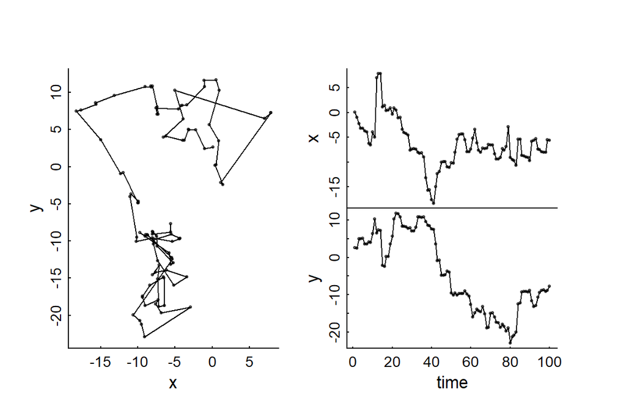

```r
pars()
scantrack(CRW())
```

Also - flies off to infinity.

Also - autocorrelated in position:

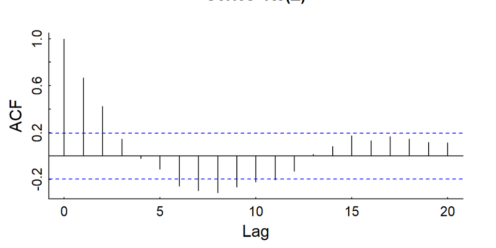

```r
acf(Re(Z))
```

but not in steps!

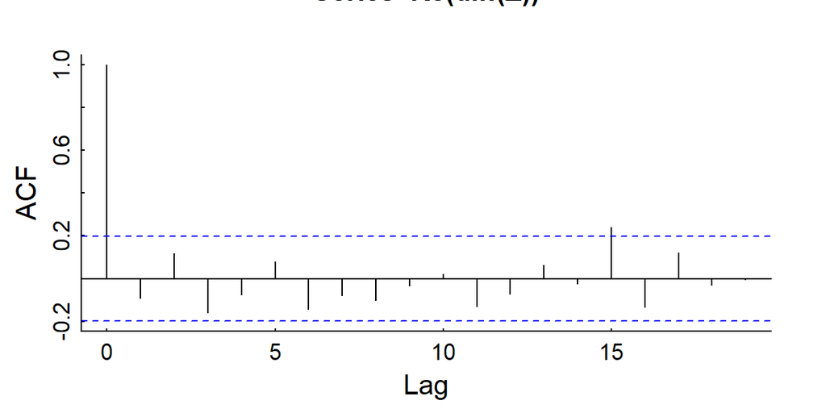

```r
acf(Re(diff(Z)))
```

(So is it really a *correlated* random walk?) ]

## Multi-state Correlated Random Walk

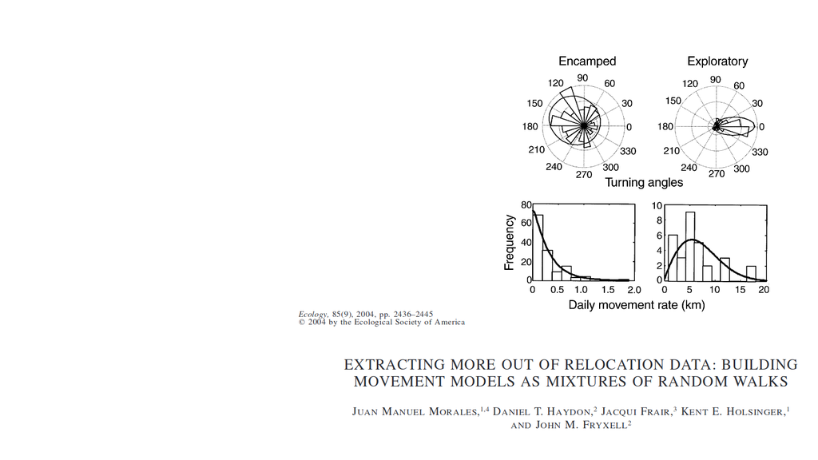

Pretty self-explanatory!

> **BUT** … what is the model of transitioning between these states?

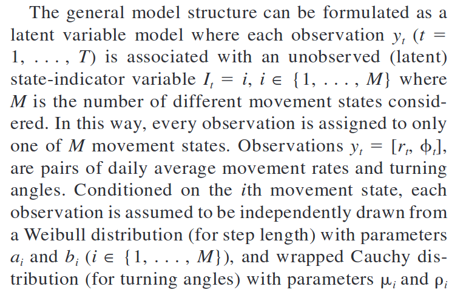

## Digression on Markov Chains

(*This should really be its own chapter!*)

Consider ${\bf X} = \{X_1,X_2,X_3, ... , X_n\}$ is in some discrete **state space** $\mathcal{E}$ (here: $A, B, C$) with fixed probabilities of transitioning from one state to another:

Sample sequence: ${\bf X} = CCCBBCACCBABCBA ...$.

This is called a **Markov chain**.

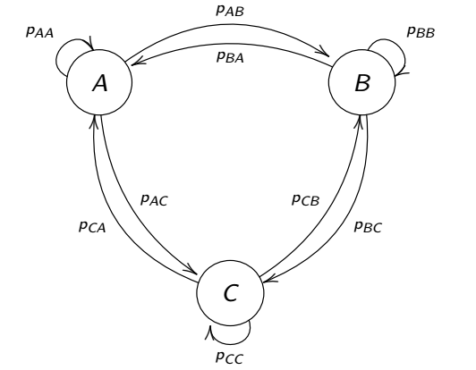

### Markov property

- The $p_{ij}(t)$’s of a Markov chain are **transition probabilities**.
- If $p_{ij}(t)$’s are time invariant, i.e. $p_{ij}(t) = p_{ij}$, the chain is called **time homogeneous** or **stationary**.

### Probability transition matrix

We express this process in terms of a **Probability Transition** matrix:

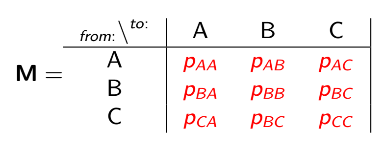

Such that:
$$M_{ij}=\Pr{(X_{t+1} = j | X_t
= i)} = p_{ij}$$
Note that:
$$\sum_{j=1}^{n} p_{ij} = 1 \ldots \text{BUT}
\ldots \sum_{i=1}^{n} p_{ij} \neq 1$$

Such that:
$$\Pr{(X_{t+1} = j)} =
\sum_{i=1}^N M_{ij} \Pr{(X_t = i)}$$
Which can be conveniently rewritten in matrix notation as:
$$\pi_{t+1}
= {\bf M} \times (\pi_{t})^T$$

Where $\pi_t$ is the distribution of the system over all states at time $t$.

### Example 1: Children play frisbee

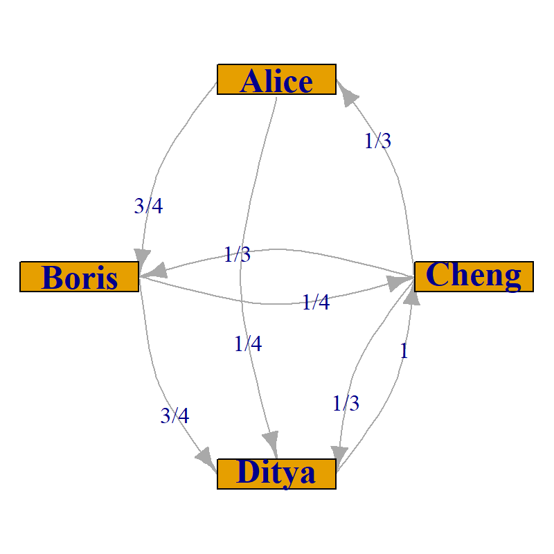

$$\large{\bf M}= \begin{array}{c|cccc|}
& A & B & C & D\\
\hline
A & 0 &3/4& 0 & 1/4\\
B &0 & 0 & 1/4 & 3/4\\
C &1/3 & 1/3 & 0 & 1/3\\
D &0 & 0& 1 & 0
\end{array}$$

Let’s give the frisbee to Alice, and see what happens:

```r
M <- rbind(c(0,3/4,0,1/4), c(0,0,1/4,3/4), c(1/3,1/3,0,1/3), c(0,0,1,0))
rownames(M) <- c("Alice", "Boris", "Cheng", "Ditya")
colnames(M) <- rownames(M)
rowSums(M)
```

```
## Alice Boris Cheng Ditya
##     1     1     1     1
```

```r
State<-1:4
X <- 1
Xs <- X
for(i in 1:30){
    X<-sample(State,1,prob=M[X,])
    Xs <- c(Xs, X)
}
paste(LETTERS[Xs], collapse="-")
```

```
## [1] "A-B-D-C-B-D-C-A-D-C-A-B-D-C-A-B-D-C-B-D-C-D-C-B-D-C-A-D-C-A-D"
```

This is called a **realization** of a stochastic process.

Let us consider this process *probabilistically*. Again, we start with Alice (click below to animate - pay attention to the probabilities )

[video not shown]

```
## [1] "pi_ 20 = 0.12,0.211,0.361,0.308"
```

The state: $\pi^* = (0.12 , 0.21 , 0.361 , 0.308)$ is referred to as **stationary**.

1. The name can be a bit confusing: the frisbee is not stationary, it is always moving around.
2. All states have a finite probablity (0 to 1) of being revisited forever and ever until the children’s arms fall off. Such states are termed **recurrent**, **persistent** or **ergodic**.
3. The state can be solved for mathematically:
   $$\pi^* = {\bf M} \times (\pi^*)^T$$

This is often quite easy to obtain.

For example, via brute force matrix multiplication:

```r
powermat=function(M,t){
  Mt <- M
  for(i in 2:t) Mt = Mt %*% M
  Mt}
powermat(M,100)
```

```
##         [,1]      [,2]      [,3]      [,4]
## PA 0.1203008 0.2105263 0.3609023 0.3082707
## PB 0.1203008 0.2105263 0.3609023 0.3082707
## PC 0.1203008 0.2105263 0.3609023 0.3082707
## PD 0.1203008 0.2105263 0.3609023 0.3082707
```

Or via matrix algebra:

```r
 n <- nrow(M)
 a <- rbind((t(M) - diag(n))[-n,], rep(1,n))
 b <- c(rep(0,n-1),1)
 solve(a, b)
```

```
##        PA        PB        PC        PD
## 0.1203008 0.2105263 0.3609023 0.3082707
```

*Think about why does this works …*

## Back to Multi-state CRW …

To simulate a multi-state CRW, first create a transition matrix:

```r
M <- rbind(c(0.7,0.2,.1), c(.4,.4,.2), c(0,0.8,0.2))
row.names(M) <- colnames(M) <- c("chilling", "cruising", "huffing")
M
```

```
##          chilling cruising huffing
## chilling      0.7      0.2     0.1
## cruising      0.4      0.4     0.2
## huffing       0.0      0.8     0.2
```

Create a vector of simulated states:

```r
n <- 400
states <- 1:nrow(M)
State <- c(1, rep(NA, n=1))
for(i in 2:n)
  State[i] <- sample(states, 1, prob=M[State[i-1],])
State[1:100]
```

[output not shown]

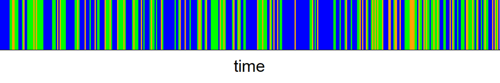

Next, assign movement steps to each state

```r
rhos <- c(0, .5, .9)
betas <- c(.5,3,8)
alphas <- c(1,2,5)

rwc <- function (n, mu, rho) {
  ifelse(rho == 0,
      runif(length(rho == 0), 0, 2*pi),
        rcauchy(n, mu, -log(rho)) %% (2 * pi))
}

thetas <- rwc(n, mu= 0, rho = rhos[State])
step_lengths <- rweibull(n, shape = alphas[State], scale = betas[State])

S <- complex(arg = cumsum(thetas), mod = step_lengths)
Z <- cumsum(S)
```

[figure not shown]

```r
cols <-  c("darkblue","green","orange")
plot(Z, type = "l", col = "darkgrey", asp = 1)
points(Z, col = cols[State], pch = 19, cex = 0.5)
legend("topright", legend = row.names(M), col = cols, pch = 19)
```

Stationary state proportions:

```
##  chilling  cruising   huffing
## 0.4848485 0.3636364 0.1515152
```

Simulated proportions:

```r
table(State) |> prop.table()
```

```
## State
##      1      2      3
## 0.5100 0.3225 0.1675
```

## Habitat dependent Multi-state random walk

The actual Morales MRW was more interesting than just transitions … each transition was modeled as **depending on covariates** ($\bf X$) according to coefficients $\beta$.

$$p_{12} = {e^{\beta {\bf X}} \over 1 +
e^{\beta {\bf X}}}$$

and $p_{11} = 1-p_{12}$. This sounds crazy complicated, but - with recent technology is - in fact - quite easy to do! (later this week)